# Cellen 2

Statistical thinking — statistical inference

Gavin Simpson

gavin@anivet.au.dk

Aarhus University

2025-03-05

## Introduction

Statistical inference relates to using probabilities to make decisions about parameters of interest in a population from statistics (estimates) derived from a subset or sample from that population

Are the population means of two groups, **control** & **treated**, different?

Key concepts

- test statistics & their distribution
- null hypothesis testing
- statistical significance
- confidence intervals

# Samples & populations

## Samples & populations

Interested in the efficacy of a new drug for treating disease in animals

The population of interest is all the animals with the disease across herds in a sector

We could recruit the farmers managing all the herds in the sector into a study, and give each animal either the new drug or a control

Measure the recovery time of the two groups

Problems are:

- would be far too costly,
- would be far too time consuming, and
- we’d never recruit **every** herd into the study

## Samples & populations

An alternative approach is to sample from the population of interest

Take a random, representative subset of animals (or herds) from the population of interest

How *representative* the sample is depends on how it was collected

## Sampling

Many statistical methods assume that the data represent a random sample from a population

Difficult to do in practice

- need to identify every individual in the target population
- some farmers or owners may refuse to be part of the study

Alternatively we could cluster sample (random stratified sampling); select *n* representative herds and then randomly sample individuals from within those herds

## Sampling error

Statistics computed on samples will be rarely exactly equal to the population values

- A sample of 20 male and 20 female penguins
- Mean bill length in male Adelie = 40.54
- Mean bill length in female Adelie = 37.36

Is there evidence of sexual dimorphism in *Adelie* penguin bill lengths?

Evidence would be that, the typical bill length of male *Adelie* penguins is **different** from the typical bill length in female *Adelie* penguins

## Samples and populations

A distinction is often made between parameters and statistics

- Parameters relate to the population: population mean
- Statistics refer to the sample: sample mean

A sample statistic is an estimate of a population parameter

Interchange between statistics and parameter estimates

## Probability

Probabilities describe the *chance* that an event will occur

Probabilities range from 0 to 1, with smaller values indicating the occurrence unlikely and larger values indicating occurrence is likely

Compute probabilities as $\displaystyle \frac{m}{M}$; $m$ is the number of possible outcomes of interest $M$ is the number of all possible outcomes

Probability of a head on a single coin toss: $\frac{1}{2} = 0.5$

Probability of rolling an odd number on a 10-side die: $\frac{5}{10} = 0.5$

Probability of rolling a value less than 3 on a 10-sided die: $\frac{2}{10} = 0.2$

## Probability

What is the probability of randomly selecting two samples with means as different as observed if the samples came from the same population?

Need to consider the **sampling error**:

- samples drawn from populations with **same** mean, any difference is due to sampling error
- samples drawn from populations with **different** means; difference is due to a real population difference

## Probability

Earlier we saw a difference of means of the bill lengths of male and female *Adelie* penguins of 3.18

- Assume that there is **no difference** between male and female *Adelie* penguin’s bill lengths
- Under this assumption we can say the mean bill length on males is equal to the mean bill length of females
  $$\mu_{\text{male}} = \mu_{\text{female}}$$
- Using a computer we can see how likely a result the observed difference is:
  1. draw at random two samples of 20 values each from a population with mean = 40.54, the male mean bill length, (& same variance)
  2. record the difference in means of these two samples
- repeat 100 times

## Probability

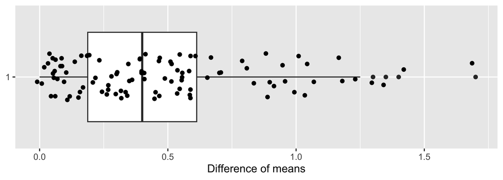

## Probability

How likely is a difference of means of >3? How likely is a difference of means of >0.5?

Read off from the cumulative distribution function of the sampling distribution of statistic

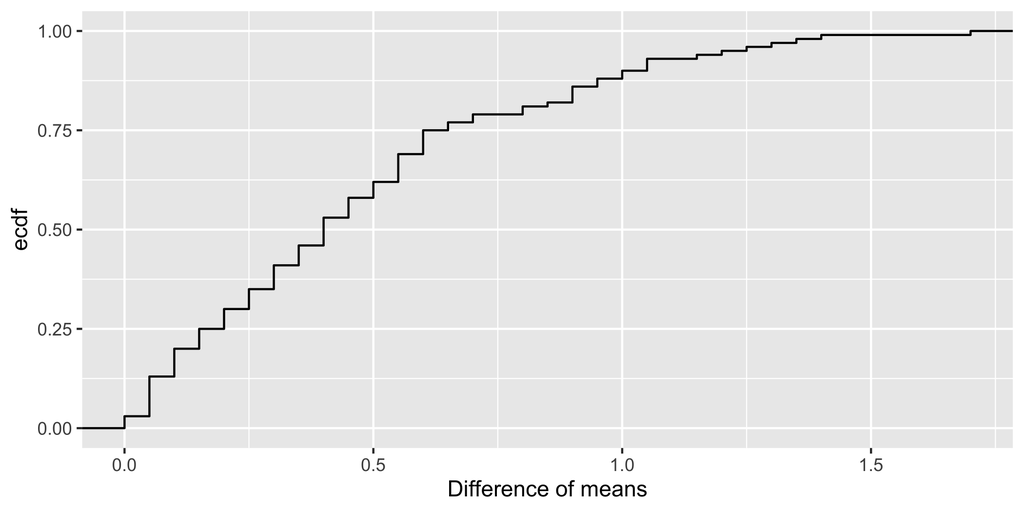

## Probability

That involved taking lots of data sets (multiple samples)

We will rarely do that in practice

- time
- money

Instead, we can work with a *single*, representative sample

# Permutation tests

## Null hypothesis

Often, the null hypothesis, $\text{H}_0$, is that there is **no effect**

> $\text{H}_0$: there is no effect of **sex** on the bill length of *Adelie* penguins

This means that, under $\text{H}_0$ we can rearrange the `sex` variable randomly, pairing any value of `bill_length_mm` with a male or female penguin

Under $\text{H}_0$, these shufflings of the data should look similar to our observed data

## Null hypothesis

Under $\text{H}_0$, these shufflings of the data should look similar to our observed data

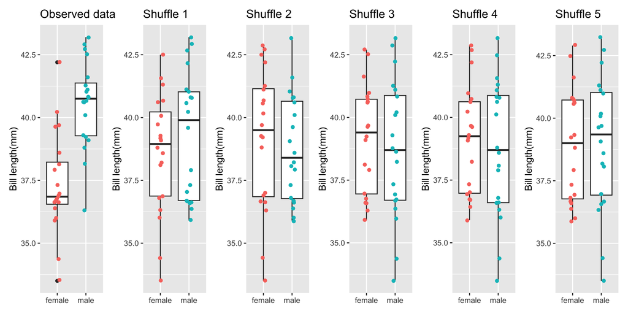

> Do the shuffled data look like the observed data?

## Permutation test

What we just did is the basis of a permutation test of $\text{H}_0$

A real test would shuffle — **permute** — the data many more times than just 5

## Permutation tests with infer 📦

```r
adelie_shuffled <- withr::with_seed(2,
  adelie_bills |>
    specify(bill_length_mm ~ sex) |>
    hypothesize(null = "independence") |>
    infer::generate(
      reps = 1000,
      type = "permute"
    )
  )
```

- model: `bill_length_mm ~ sex` — estimate the extent to which the observed lengths of bill depend on whether a penguin is male or female
- $\text{H}_0: \hat{\mu}_{\text{Males}} = \hat{\mu}_{\text{Females}}$
- 1000 permutations

```
## Response: bill_length_mm (numeric)
## Explanatory: sex (factor)
## Null Hypothesis: independence
## # A tibble: 40,000 × 3
## # Groups:   replicate [1,000]
##    bill_length_mm sex    replicate
##             <dbl> <fct>      <int>
##  1           41.1 female         1
##  2           39.6 female         1
##  3           36.9 female         1
##  4           40.1 female         1
##  5           42.7 female         1
##  6           38.1 female         1
##  7           36.7 female         1
##  8           40.6 female         1
##  9           39.2 female         1
## 10           36.6 female         1
## # ℹ 39,990 more rows
```

## Permutation tests with infer 📦

We also wrapped all that in `withr::with_seed()`, which is another way of setting random seeds for the RNG

## Permutation tests with infer 📦

Now we have 1,000 randomly shuffled — **permuted** — data sets

Our null hypothesis ($\text{H}_0$) is that there is

> no difference in the mean bill length of male and female *Adelie* penguins

For each permuted data set we need to calculate the

1. mean `bill_length_mm` for the males: $\hat{\mu}_{\text{Males}}$
2. mean `bill_length_mm` for the females: $\hat{\mu}_{\text{Females}}$
3. the **difference** of these two means: $\hat{\mu}_{\text{Males}} - \hat{\mu}_{\text{Females}}$

This difference of means will be our test statistic

## Permutation tests with infer 📦

We could do those calculations using **dplyr** but **infer** makes it even easier via `calculate()`

```r
adelie_null_distribution <- adelie_shuffled |>
  calculate(stat = "diff in means", order = c("male", "female"))
```

- `"diff in means"` is how we indicate we want a difference of means
- `order` indicates the order of the means in the difference

The order doesn’t matter, so long as we are *consistent*

We did $\hat{\mu}_{\text{Males}} - \hat{\mu}_{\text{Females}}$ so we will put `male` first

This generates the null distribution of the test statistic

## Null distribution

The null distribution shows the distribution of the test statistic under $\text{H}_0$ of no effect

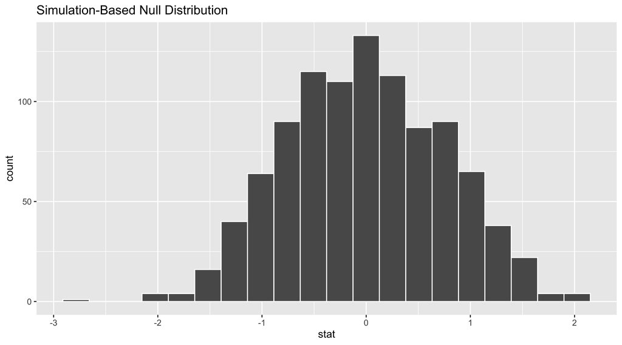

## Observed value

We also need to compute the observed value of the test statistic (i.e. the one for our data)

Do this using the same pipeline, *without* the `hypothesize()` and `generate()` steps

```r
obs_diff_means <- adelie_bills |>
  specify(bill_length_mm ~ sex) |>
  calculate(stat = "diff in means", order = c("male", "female"))

obs_diff_means
## Response: bill_length_mm (numeric)
## Explanatory: sex (factor)
## # A tibble: 1 × 1
##    stat
##   <dbl>
## 1  3.18
```

## Null distribution

If we add the the observed value to the plot we can see how typical our observed difference of means is to the values we would expect if there was **no effect** of `sex`

```r
visualise(adelie_null_distribution, bins = 20) +
  shade_p_value(obs_stat = obs_diff_means, direction = "both")
```

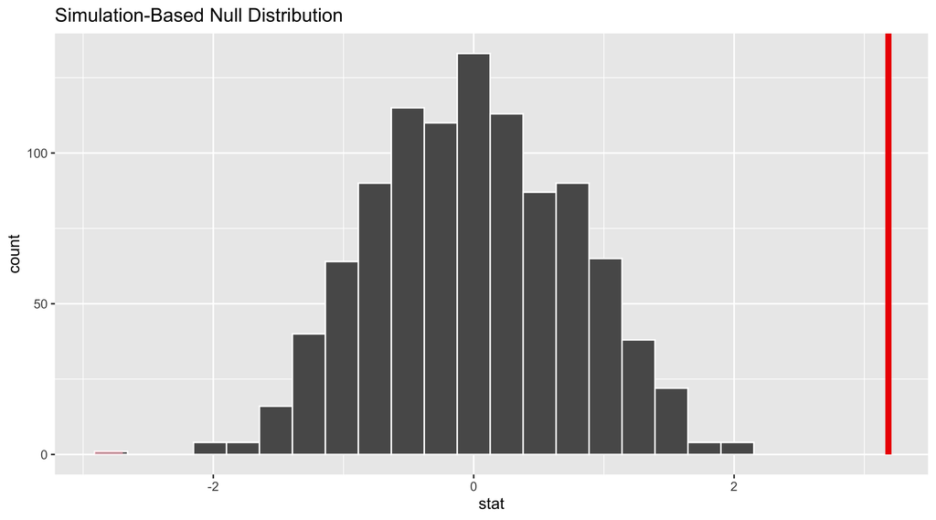

## One tail or two?

Whether a test is one- or two-tailed is a common distinction in research studies

Relates to the alternative hypothesis:

- do we hypothesize only that the means are different?, or
- do we hypothesize that the mean of the males is greater (less) than the females?

This is where concept of one- or two-tailed tests comes from; in which tail do we find the rejection region

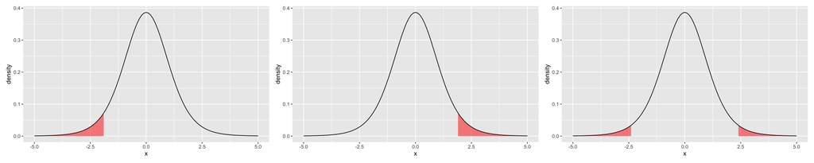

## Null distribution

If we add the the observed value to the plot we can see how typical our observed difference of means is to the values we would expect if there was **no effect** of `sex`

We asked for `direction = "both"` so the alternative hypothesis is that the males and females have different mean bill lengths

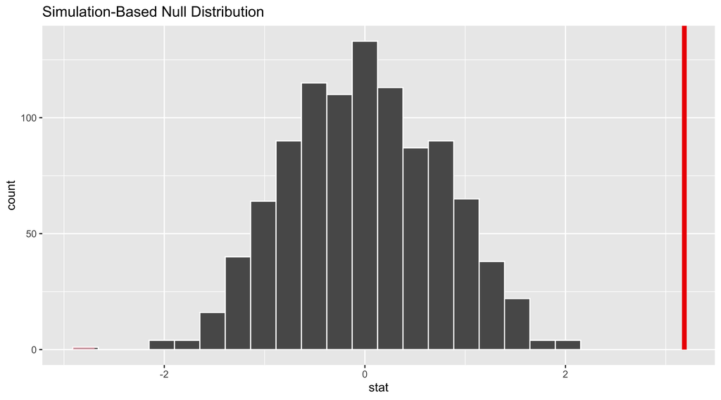

## Alternative hypothesis

We typically denote the alternative hypothesis as $\text{H}_1$ or $\text{H}_{\text{a}}$

This hypothesis is usually what we are interested in knowing about, but we can’t test it explicitly

$\text{H}_{\text{a}}$ could be:

1. that male and female *Adelie* penguins have **different** bill lengths on average, or
2. that male *Adelie* penguins have **longer** bill lengths on average than females, or
3. that male *Adelie* penguins have **shorter** bill lengths on average than females

## Alternative hypothesis

1. that male and female *Adelie* penguins have **different** bill lengths on average, or
2. that male *Adelie* penguins have **longer** bill lengths on average than females, or
3. that male *Adelie* penguins have **shorter** bill lengths on average than females

Option 1 is a two-sided test so we set `direction` to be `"two-sided"` or `"both"`

Option 2 is a one-sided test so we set `direction` to be `"greater"` or `"right"`

Option 3 is also a one-sided test but we set `direction` to be `"less"` or `"left"`

(for `order = c("male", "female")`!)

## Alternative hypothesis

Before observing the penguins, if we had hypothesized that males had longer bills than females, we could have done a one-sided of the hypothesis

> male *Adelie* penguins have **longer** bill lengths on average than females

$$\begin{align*}
\text{H}_{\text{0}} & : \hat{\mu}_{\text{Males}} = \hat{\mu}_{\text{Females}} \\
\text{H}_{\text{a}} & : \hat{\mu}_{\text{Males}} > \hat{\mu}_{\text{Females}}
\end{align*}$$

## Alternative hypothesis

It might be easier to express our hypotheses in terms of the **difference of means**

#### Two-tailed

$$\begin{align*}
\text{H}_{\text{0}} & : \hat{\mu}_{\text{Males}} - \hat{\mu}_{\text{Females}} = 0 \\
\text{vs H}_{\text{a}} & : \hat{\mu}_{\text{Males}} - \hat{\mu}_{\text{Females}} \neq 0
\end{align*}$$

#### One-tailed

##### `"less"`

$$\begin{align*}
\text{H}_{\text{0}} & : \hat{\mu}_{\text{Males}} - \hat{\mu}_{\text{Females}} = 0 \\
\text{vs H}_{\text{a}} & : \hat{\mu}_{\text{Males}} - \hat{\mu}_{\text{Females}} < 0
\end{align*}$$

##### `"greater"`

$$\begin{align*}
\text{H}_{\text{0}} & : \hat{\mu}_{\text{Males}} - \hat{\mu}_{\text{Females}} = 0 \\
\text{vs H}_{\text{a}} & : \hat{\mu}_{\text{Males}} - \hat{\mu}_{\text{Females}} > 0
\end{align*}$$

## Alternative hypothesis

```r
visualise(adelie_null_distribution, bins = 20) +
  shade_p_value(obs_stat = obs_diff_means, direction = "greater")
```

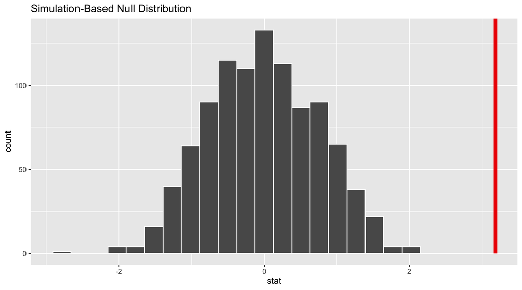

## Don’t change your mind

You *must* decide what kind of $\text{H}_{\text{a}}$ you want to test *before* you observe (or analyse) the data

You can’t use a two-sided alternative
$$\text{H}_{\text{a}} : \hat{\mu}_{\text{Males}} - \hat{\mu}_{\text{Females}} \neq 0$$

and reject $\text{H}_{\text{0}}$, noting that males have longer bills than females and **then** decide to use the more powerful alternative

$$\text{H}_{\text{a}} : \hat{\mu}_{\text{Males}} - \hat{\mu}_{\text{Females}} > 0$$

## The *p*-value of the test

Using the null distribution we can obtain a *p*-value

> the probability that a test statistic as or more extreme than the observed statistic would occur **if the null hypothesis were true**

We count how many difference of means in the null distribution are

- equal to or greater than (in absolute value)
- greater than, or
- less than

the observed difference of means $\hat{\mu}_{\text{Males}} - \hat{\mu}_{\text{Females}}$

Why “in absolute value” for the two-sided test?

## The *p*-value of the test

In our case, the *p*-value is reported to be 0

```r
# p value for the simpler alternative of the bill lengths are different
adelie_null_distribution |>
  get_p_value(obs_stat = obs_diff_means, direction = "two-sided")
## # A tibble: 1 × 1
##   p_value
##     <dbl>
## 1       0
```

This doesn’t make sense so instead we say the $p$ is less than 0.001

$$\text{p value} = p = \frac{1}{P}$$

$P$ is the number of permuted data sets we generated (we had $P = 1000$ here)

# Null Hypothesis Significance Testing

## NHST

This is the basis of Null Hypothesis Significance Testing or NHST

The null hypothesis is the situation we test; no difference in means between groups, no relationship between *x* and *y*

Look for **evidence** against this null hypothesis; unlikely values of statistics if the *null hypothesis were true*

We permuted the data to generate the null distribution of the test statistic

> the sampling distribution of the test statistic under $\text{H}_0$

Much theoretical work in statistics is in deriving sampling distributions of different statistics, or types of statistics, using maths instead of resampling (permuting)

## Standard normal distribution

The standard normal distribution is a Gaussian distribution with $\mathsf{\mu = 0}$ & $\mathsf{\sigma^2 = 1}$

People often call values from this distribution **z-scores**

Calculate *z*-scores by subtracting the mean score from each score and dividing by $\sigma$

$$z_i = \mathsf{\frac{\text{score}_i - \text{mean}}{\text{standard deviation}}}$$

$$z_i = \mathsf{\frac{14 - \text{14.95}}{\text{5.47}}} = \mathsf{-0.17}$$

Negative *z*-scores lie below the sample mean, positive scores above it

## Standard normal distribution

**68%** probability *z*-score lies between -1–1; **95%** probability *z*-score lies between -1.96–1.96

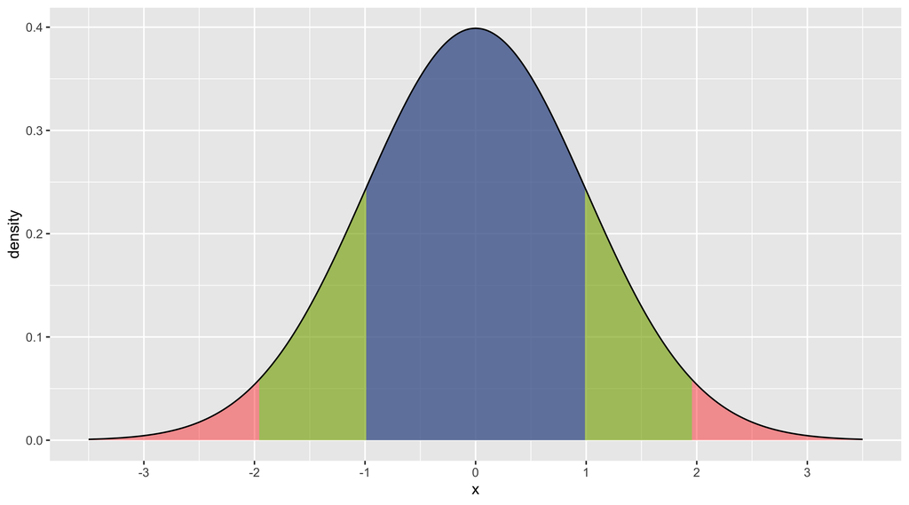

## The *p*-value

Probability distributions, like the standard normal or *t* distribution, help us compute the probability of obtaining a statistics if the null hypothesis were true

This is the probability due the **chance**

Under standard normal, probability of observing a score of 2.5 is 0.006

Under *t* distribution with 5 df, probability of observing a score of 2.5 is 0.027

*t* distribution often used for small samples & where sample variance is estimated (not know) which for many samples will be an underestimate of the true variance

**The *p*-value tells us *nothing* about the probability of the null hypothesis or the alternative hypothesis**

## *t* and normal distributions

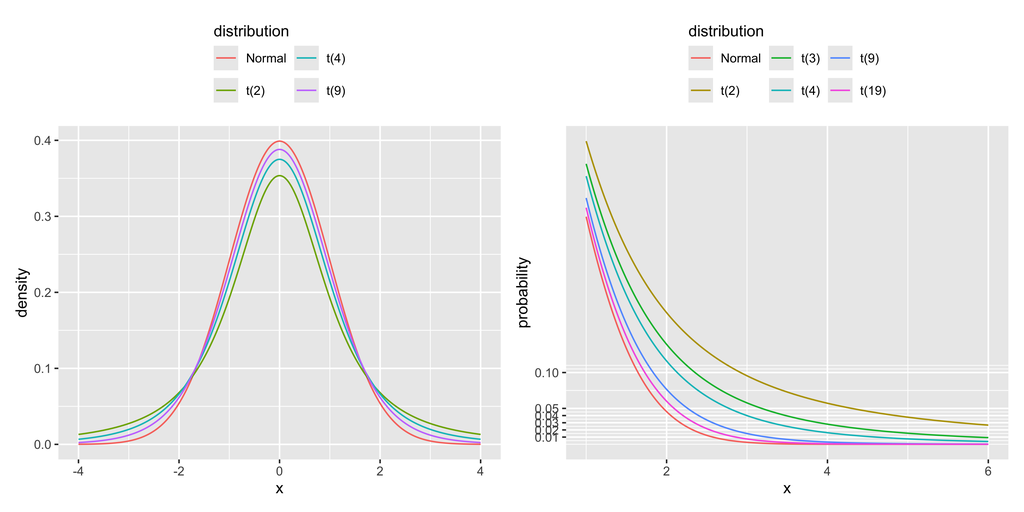

Redrawn from **Krzywinski & Altman** (2013) [Significance, *P* values and *t*-tests](http://doi.org/10.1038/nmeth.2698). *Nature Methods* **10**(11) 1041–1042 [doi: 10.1038/nmeth.2698](http://doi.org/10.1038/nmeth.2698)

## One- and two-tailed tests

Whether a test is one- or two-tailed is a common distinction in research studies

Relates to the hypothesis:

- do we hypothesize only that the means are different?, or
- do we hypothesize that the mean of the treated group is greater (less) than the control?

This is where concept of one- or two-tailed tests comes from; in which tail do we find the rejection region

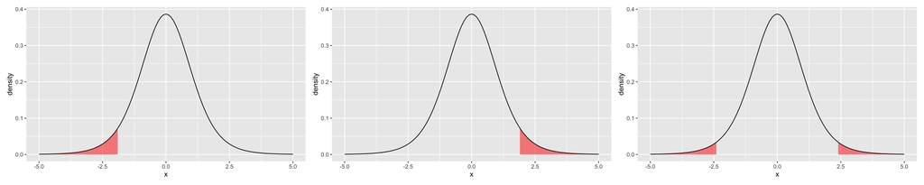

## Theoretical test

The classical test for a difference of means is known as a two-sample *t* test

```
##
##  Two Sample t-test
##
## data:  bill_length_mm by sex
## t = -5.4197, df = 38, p-value = 3.557e-06
## alternative hypothesis: true difference in means between group female and group male is not equal to 0
## 95 percent confidence interval:
##  -4.374686 -1.995314
## sample estimates:
## mean in group female   mean in group male
##               37.355               40.540
```

## Theoretical test

The two-sample *t* test is a special case of a linear model

```r
m <- lm(bill_length_mm ~ sex, data = adelie_bills)
summary(m)
##
## Call:
## lm(formula = bill_length_mm ~ sex, data = adelie_bills)
##
## Residuals:
##     Min      1Q  Median      3Q     Max
## -4.2400 -1.0262  0.0025  0.8350  4.8450
##
## Coefficients:
##             Estimate Std. Error t value Pr(>|t|)
## (Intercept)  37.3550     0.4155   89.89  < 2e-16 ***
## sexmale       3.1850     0.5877    5.42 3.56e-06 ***
## ---
## Signif. codes:  0 '***' 0.001 '**' 0.01 '*' 0.05 '.' 0.1 ' ' 1
##
## Residual standard error: 1.858 on 38 degrees of freedom
## Multiple R-squared:  0.436,  Adjusted R-squared:  0.4211
## F-statistic: 29.37 on 1 and 38 DF,  p-value: 3.557e-06
```

## Theoretical test

The two-sample *t* test is a special case of a linear model

```r
library("marginaleffects")

avg_comparisons(m)
##
##  Estimate Std. Error    z Pr(>|z|)    S 2.5 % 97.5 %
##      3.19      0.588 5.42   <0.001 24.0  2.03   4.34
##
## Term: sex
## Type:  response
## Comparison: male - female
```

This compares the estimated mean bill lengths for male and female penguins

`Estimate` is the estimated difference of means

`Std. Error` is the *uncertainty* in the estimate difference

`z` is the test statistic and `Pr(>|z|)` is the *p* value

We will focus on linear models on this course

## Type I and Type II errors

In NHST we obtain the probability ($p$) of observing as extreme a statistic as the observed *if the null hypothesis were true*: evidence *against* the null

If $p$ is small we **reject** the null hypothesis & accept the alternative: chance that we falsely reject the Null

If $p$ is large we **fail to reject** the null hypothesis & thus **reject** the alternative: chance that we falsely fail to reject the Null

##### No effect in population

- Reject null hypothesis: Type I error
- Fail to reject null hypothesis: *correct decision*

##### Effect in population

- Reject null hypothesis: *correct decision*
- Fail to reject null hypothesis: Type II error

## Statistical Significance

- What is a small *p*-value?
- A typical value is $p \leq 0.05$, which means 5% Type I error rate, or 5 times in 100 you’d expect to see as extreme a statistic as the observed *purely due to chance* *if* $\text{H}_0$ is **true**
- In other words; you’d **falsely** reject the null hypothesis, on average, 5 times in 100
- Might be OK for some studies or research
- Probably not OK for making life & death decisions or declaring you’ve found a new elementary particle
- Particle physicists use 5 sigma: need a *p* <= ~0.000000287 to reject the null!

There is nothing special about $p \leq 0.05$

## Problems with NHST: Effect Size

A major problem with peoples’ use of NHST is the over-emphasis put on the *p*-value

The *p*-value is just a measure of conditional probability; just because you get a low *p*-value doesn’t mean the effect is **important**

Increase the sample size and, all things equal, you can detect smaller effects (statistically significant effects)

Important to ask if the effect size is important or relevant?

**Effect size** refers to the

- magnitude of the difference between groups
- magnitude of the relationship between $x$ and $y$

## Problems with NHST: power

Statistical power is the ability of a study to **detect** a real effect

**Power** is a function of the Type II error:

$$\mathsf{power} = 1 - \beta$$

Power ranges from **0** (no chance of detecting the real effect) to **1** (100% chance of detecting the real effect)

There is no point in conducting a study, especially one involving animals, that has low chance of finding the real effect

## Problems with NHST: power

Power is a function of several important factors

1. **Sample size** — the larger the sample size the greater the power to detect an effect of a given size
2. **Criterion** for significance ($\mathsf{\alpha = 0.05}$ say) — the lower $\mathsf{\alpha}$, the less likely you are to reject the null hypothesis
3. **One- or two-tailed tests** — one-tailed tests are typically more powerful than two-tailed ones; making a stronger statement about the expected effect
4. **Effect size** — the bigger the effect the study tries to detect the greater the power

For simple models (*t*-tests, one-way ANOVA, etc) there are relatively simple equations for computing the power of a planned study for given sample size, effect size etc.

For more complex models, power calculations become difficult; simulation using a computer is a solution

# Confidence Intervals

## Confidence Intervals

In NHST, too much emphasis is placed on just the sample statistic (mean, difference of means, regression slope $\beta_j$, etc)

A different way of presenting statistical results is the confidence interval

Confidence intervals can be interpreted as (from Wikipedia)

- Were this procedure to be repeated on multiple samples, the calculated confidence interval (which would differ for each sample) would encompass the true population parameter 95% of the time
- There is a 95% probability that the calculated confidence interval from some future experiment encompasses the true value of the population parameter
- The confidence interval represents values for the population parameter for which the difference between the parameter and the observed estimate is not statistically significant at the 5% level

## Confidence intervals

To a frequentist a 95% confidence interval either *includes* the “true” value or it doesn’t

A frequentist thinks like this: if we

1. redid the experiment *many* times,
2. collected new data each time,
3. repeated the same analysis, and
4. computed the confidence interval for each replication

95% of those confidence intervals will include the “true” value

Here “true” value = 0.5

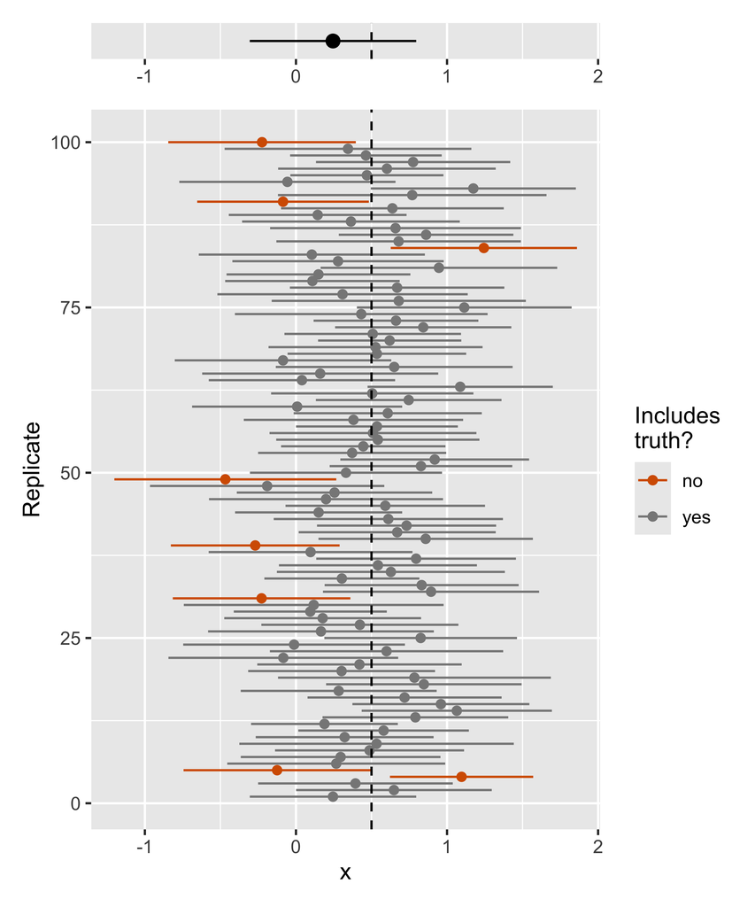

## Confidence intervals

As with the resampling (permutation) and theoretical approaches we used for hypothesis testing we can compute a resampling or theoretical version of a confidence interval

The resampling version uses a non-parametric bootstrap procedure

## Bootstrap

The standard error of the mean (SEM)

> the estimated standard deviation of the means of all possible samples of the variable

Rather than use this theoretical result we could resample the data to generate the sampling distribution

In stead of permuting the data (resampling without replacement) we’ll use resampling **with** replacement

**With replacement** means that each time we draw a single data point to add to our sample, we put it back so it can be drawn again

## Bootstrap

A single bootstrap sample then is the same size as our data

But it will include repeats of some of the observed values

This also means some values in the data won’t be in a bootstrap sample

## Bootstrap

A single bootstrap sample can be generated using `rep_sample_n()`

Set `replace = TRUE` to get a bootstrap sample instead of a permutation

```r
adelie_bills |>
  rep_sample_n(
    size = 40,
    replace = TRUE
  ) |>
  select(replicate, bill_length_mm, sex)
## # A tibble: 40 × 3
## # Groups:   replicate [1]
##    replicate bill_length_mm sex
##        <int>          <dbl> <fct>
##  1         1           36.7 female
##  2         1           36.4 female
##  3         1           36.4 female
##  4         1           42.7 male
##  5         1           35.9 female
##  6         1           38.2 male
##  7         1           37.9 female
##  8         1           39.2 male
##  9         1           43.2 male
## 10         1           36.6 female
## # ℹ 30 more rows
```

## Bootstrap

To generate multiple samples, set `reps`

```r
adelie_bills |>
  rep_sample_n(
    size = 40,
    replace = TRUE,
    reps = 21
  ) |>
  select(replicate, bill_length_mm, sex)
## # A tibble: 840 × 3
## # Groups:   replicate [21]
##    replicate bill_length_mm sex
##        <int>          <dbl> <fct>
##  1         1           42.2 female
##  2         1           39.3 male
##  3         1           40.6 male
##  4         1           37.9 female
##  5         1           40.1 male
##  6         1           38.1 female
##  7         1           36.8 female
##  8         1           38.2 male
##  9         1           39.1 male
## 10         1           36.9 female
## # ℹ 830 more rows
```

## Bootstrap

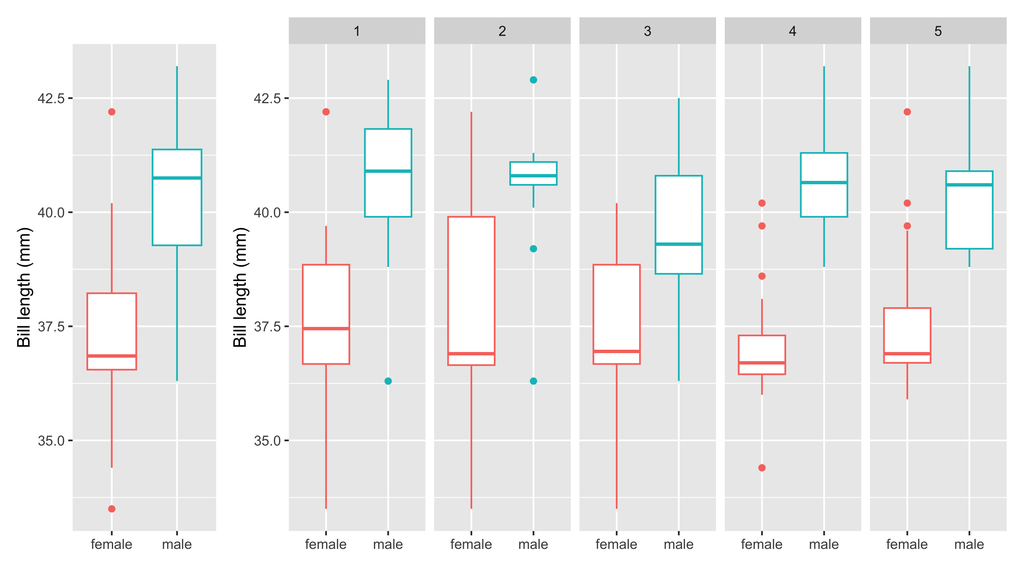

## Bootstrap CI

Can use the bootstrap to generate a CI for the mean bill length of the male *Adelie* penguins

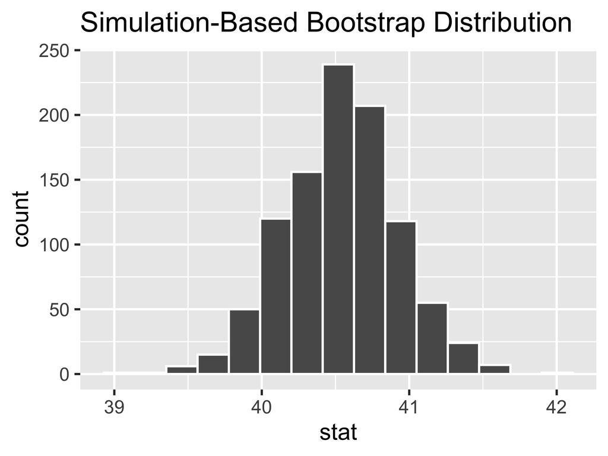

```r
male_boot <- adelie_bills |>
  filter(sex == "male") |>
  specify(response = bill_length_mm) |>
  generate(
    reps = 1000,
    type = "bootstrap") |>
  calculate("mean")

male_boot |>
  visualize()
```

## Bootstrap CI

The percentile CI uses percentiles of the distribution. E.g. for 95% CI

- lower endpoint is 0.025 quantile (2.5%)
- upper endpoint is 0.975 quantile (97.5%)

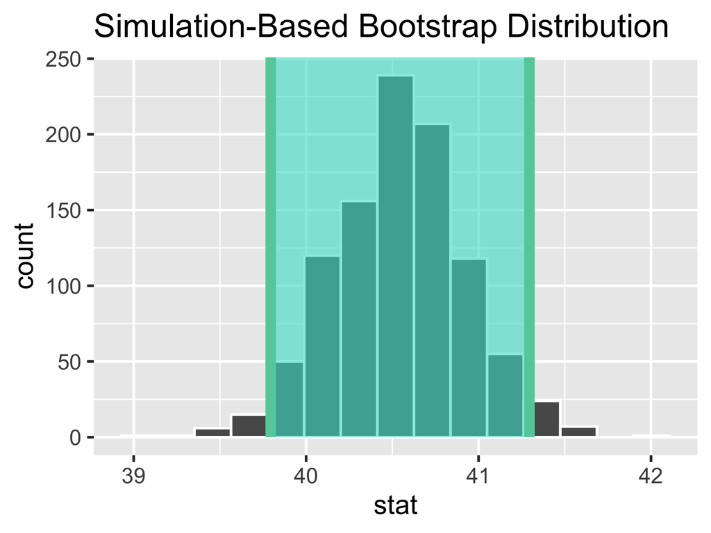

```r
male_ci <- male_boot |>
  get_ci(type = "percentile", level = 0.95)

male_boot |>
  visualize() +
  shade_ci(endpoints = male_ci)
```

Interval: 39.79 – 41.3mm

## Bootstrap

Difference of means of 21 bootstrap samples of the *Adelie* penguin bill lengths

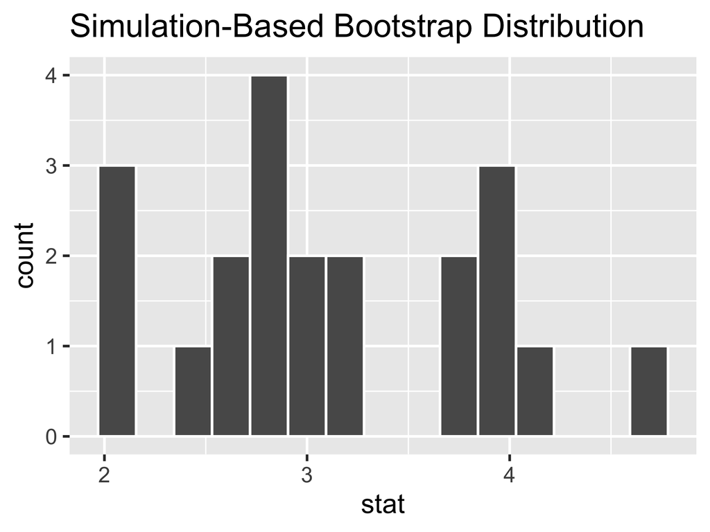

```r
adelie_bills |>
  specify(bill_length_mm ~ sex) |>
  generate(
    reps = 21,
    type = "bootstrap") |>
  calculate(
    stat = "diff in means",
    order = c("male", "female")) |>
  visualize()
```

21 samples is too small to do much with

## Bootstrap

Difference of means of 1000 bootstrap samples of the *Adelie* penguin bill lengths

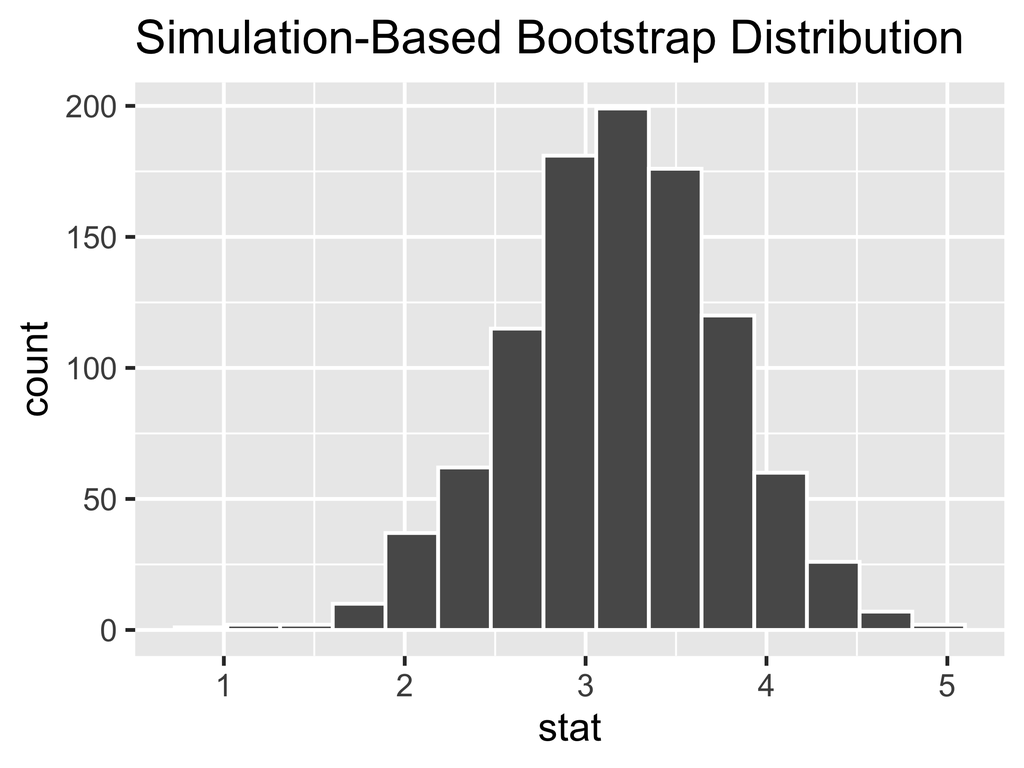

```r
boot_distn <- adelie_bills |>
  specify(bill_length_mm ~ sex) |>
  generate(
    reps = 1000,
    type = "bootstrap") |>
  calculate(
    stat = "diff in means",
    order = c("male", "female"))

visualize(boot_distn)
```

## Percentile CI

```r
pc_ci <- boot_distn |>
  get_ci(type = "percentile", level = 0.95)

pc_ci
## # A tibble: 1 × 2
##   lower_ci upper_ci
##      <dbl>    <dbl>
## 1     2.02     4.27
```

Does the confidence interval include 0?

## Percentile CI

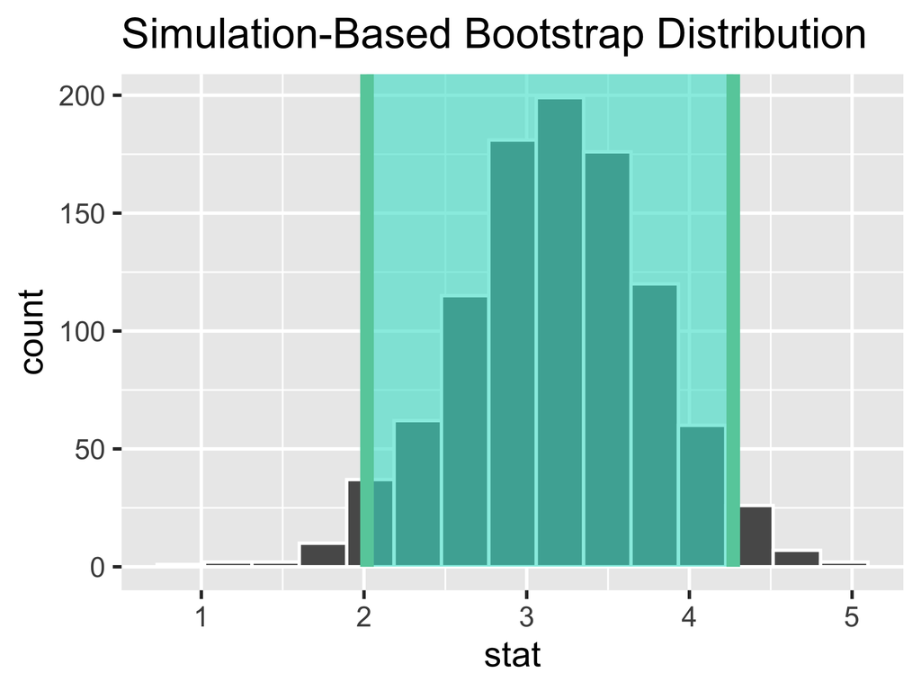

```r
boot_distn |>
  visualize() +
  shade_ci(endpoints = pc_ci)
```

## Theoretical CIs

Theoretical CI for the mean bill length for the male penguins

- **Mean of the males** — 40.54; **SD of the males** — 1.71
- **Standard error of mean** — $\frac{\hat{\sigma}}{\sqrt{n}} = \frac{1.71}{\sqrt{20}} = \frac{1.71}{4.47} = 0.38$
- **Critical value of *t* for 95% test** — 2.093
  - `qt(0.025, df = 20-1, lower.tail = FALSE)`
- **95% Confidence interval is**

  $$\mathsf{CI} = \overline{y} \pm (2.093 \times \mathsf{SEM})$$
- **Lower CI limit** — 39.74
- **Upper CI limit** — 41.34

## Theoretical CIs

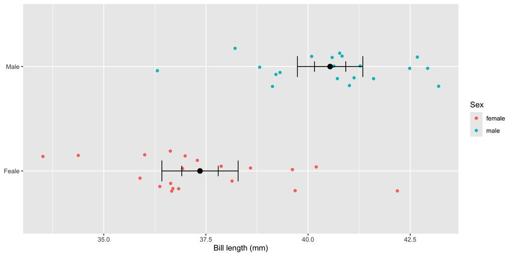

## Theoretical CIs

The theoretical 95% CI for the difference of means for the male and female *Adelie* penguins is: 1.99 – 4.38

The bootstrap 95% CI is: 2.02 – 4.27

## Resampling inference

Resampling-based inference is a general approach to inference in statistics

Theoretical approaches developed in era of no computers

Resampling methods exploit fast computation

Fewer assumptions, but some assumptions remain

Theoretical approaches still have their place